# Risk Factor Analysis

## Outcome Variable

**Outcome Variable:** haz

## Predictor Variables

**Intervention Variable:** gagebrth

**Adjustment Set:**

- arm
- sex
- W_mage
- meducyrs
- feducyrs
- hhwealth_quart
- W_nrooms
- W_nchldlt5
- brthmon
- W_parity
- impsan
- delta_W_mage
- delta_meducyrs
- delta_feducyrs
- delta_hhwealth_quart
- delta_W_nrooms
- delta_W_nchldlt5
- delta_brthmon
- delta_W_parity
- delta_impsan

## Stratifying Variables

The analysis was stratified on these variable(s):

- agecat
- studyid
- country

## Data Summary

| agecat | studyid | country | gagebrth | n_cell | n |
| --- | --- | --- | --- | --- | --- |
| Birth | ki1000108-CMC-V-BCS-2002 | INDIA | Full or late term | 58 | 92 |
| Birth | ki1000108-CMC-V-BCS-2002 | INDIA | Preterm | 11 | 92 |
| Birth | ki1000108-CMC-V-BCS-2002 | INDIA | Early term | 23 | 92 |
| Birth | ki1000108-IRC | INDIA | Full or late term | 238 | 369 |
| Birth | ki1000108-IRC | INDIA | Preterm | 36 | 369 |
| Birth | ki1000108-IRC | INDIA | Early term | 95 | 369 |
| Birth | ki1000109-EE | PAKISTAN | Full or late term | 11 | 240 |
| Birth | ki1000109-EE | PAKISTAN | Preterm | 182 | 240 |
| Birth | ki1000109-EE | PAKISTAN | Early term | 47 | 240 |
| Birth | ki1017093c-NIH-Crypto | BANGLADESH | Full or late term | 162 | 732 |
| Birth | ki1017093c-NIH-Crypto | BANGLADESH | Preterm | 257 | 732 |
| Birth | ki1017093c-NIH-Crypto | BANGLADESH | Early term | 313 | 732 |
| Birth | ki1101329-Keneba | GAMBIA | Full or late term | 2 | 11 |
| Birth | ki1101329-Keneba | GAMBIA | Preterm | 2 | 11 |
| Birth | ki1101329-Keneba | GAMBIA | Early term | 7 | 11 |
| Birth | ki1119695-PROBIT | BELARUS | Full or late term | 7098 | 13890 |
| Birth | ki1119695-PROBIT | BELARUS | Preterm | 472 | 13890 |
| Birth | ki1119695-PROBIT | BELARUS | Early term | 6320 | 13890 |
| Birth | ki1135781-COHORTS | GUATEMALA | Full or late term | 341 | 617 |
| Birth | ki1135781-COHORTS | GUATEMALA | Preterm | 95 | 617 |
| Birth | ki1135781-COHORTS | GUATEMALA | Early term | 181 | 617 |
| Birth | ki1135781-COHORTS | INDIA | Full or late term | 570 | 1293 |
| Birth | ki1135781-COHORTS | INDIA | Preterm | 285 | 1293 |
| Birth | ki1135781-COHORTS | INDIA | Early term | 438 | 1293 |
| Birth | ki1135781-COHORTS | PHILIPPINES | Full or late term | 1164 | 3024 |
| Birth | ki1135781-COHORTS | PHILIPPINES | Preterm | 649 | 3024 |
| Birth | ki1135781-COHORTS | PHILIPPINES | Early term | 1211 | 3024 |
| Birth | kiGH5241-JiVitA-3 | BANGLADESH | Full or late term | 13089 | 25394 |
| Birth | kiGH5241-JiVitA-3 | BANGLADESH | Preterm | 5265 | 25394 |
| Birth | kiGH5241-JiVitA-3 | BANGLADESH | Early term | 7040 | 25394 |

[output cut: 66 more lines]

The following strata were considered:

- agecat: 24 months, studyid: ki1000108-CMC-V-BCS-2002, country: INDIA
- agecat: 24 months, studyid: ki1000108-IRC, country: INDIA
- agecat: 24 months, studyid: ki1000109-EE, country: PAKISTAN
- agecat: 24 months, studyid: ki1017093c-NIH-Crypto, country: BANGLADESH
- agecat: 24 months, studyid: ki1066203-TanzaniaChild2, country: TANZANIA, UNITED REPUBLIC OF
- agecat: 24 months, studyid: ki1101329-Keneba, country: GAMBIA
- agecat: 24 months, studyid: ki1119695-PROBIT, country: BELARUS
- agecat: 24 months, studyid: ki1135781-COHORTS, country: GUATEMALA
- agecat: 24 months, studyid: ki1135781-COHORTS, country: INDIA
- agecat: 24 months, studyid: ki1135781-COHORTS, country: PHILIPPINES
- agecat: 24 months, studyid: kiGH5241-JiVitA-3, country: BANGLADESH
- agecat: 6 months, studyid: ki1000108-CMC-V-BCS-2002, country: INDIA
- agecat: 6 months, studyid: ki1000108-IRC, country: INDIA
- agecat: 6 months, studyid: ki1000109-EE, country: PAKISTAN
- agecat: 6 months, studyid: ki1017093c-NIH-Crypto, country: BANGLADESH
- agecat: 6 months, studyid: ki1066203-TanzaniaChild2, country: TANZANIA, UNITED REPUBLIC OF
- agecat: 6 months, studyid: ki1101329-Keneba, country: GAMBIA
- agecat: 6 months, studyid: ki1119695-PROBIT, country: BELARUS
- agecat: 6 months, studyid: ki1135781-COHORTS, country: GUATEMALA
- agecat: 6 months, studyid: ki1135781-COHORTS, country: INDIA
- agecat: 6 months, studyid: ki1135781-COHORTS, country: PHILIPPINES
- agecat: 6 months, studyid: kiGH5241-JiVitA-3, country: BANGLADESH
- agecat: Birth, studyid: ki1000108-CMC-V-BCS-2002, country: INDIA
- agecat: Birth, studyid: ki1000108-IRC, country: INDIA
- agecat: Birth, studyid: ki1000109-EE, country: PAKISTAN
- agecat: Birth, studyid: ki1017093c-NIH-Crypto, country: BANGLADESH
- agecat: Birth, studyid: ki1101329-Keneba, country: GAMBIA
- agecat: Birth, studyid: ki1119695-PROBIT, country: BELARUS
- agecat: Birth, studyid: ki1135781-COHORTS, country: GUATEMALA
- agecat: Birth, studyid: ki1135781-COHORTS, country: INDIA
- agecat: Birth, studyid: ki1135781-COHORTS, country: PHILIPPINES
- agecat: Birth, studyid: kiGH5241-JiVitA-3, country: BANGLADESH

### Dropped Strata

Some strata were dropped due to rare outcomes:

- agecat: Birth, studyid: ki1101329-Keneba, country: GAMBIA
- agecat: 24 months, studyid: ki1066203-TanzaniaChild2, country: TANZANIA, UNITED REPUBLIC OF

## Methods Detail

We’re interested in the causal parameters $E[Y_a]$ for all values of $a \in \mathcal{A}$. These parameters represent the mean outcome if, possibly contrary to fact, we intervened to set all units to have $A=a$. Under the randomization and positivity assumptions, these are identified by the statistical parameters $\psi_a=E_W[E_{Y|A,W}(Y|A=a,W)]$. In addition, we’re interested in the mean of $Y$, $E[Y]$ under no intervention (the observed mean). We will estimate these parameters by using SuperLearner to fit the relevant likelihood factors – $E_{Y|A,W}(Y|A=a,W)$ and $p(A=a|W)$, and then updating our likelihood fit using a joint TMLE.

For unadjusted analyses ($W=\{\}$), initial likelihoods were estimated using Lrnr_glm to estimate the simple $E(Y|A)$ and Lrnr_mean to estimate $p(A)$. For adjusted analyses, a small library containing Lrnr_glmnet, Lrnr_xgboost, and Lrnr_mean was used.

Having estimated these parameters, we will then use the delta method to estimate relative risks and attributable risks relative to a prespecified baseline level of $A$.

# Results Detail

## Results Plots

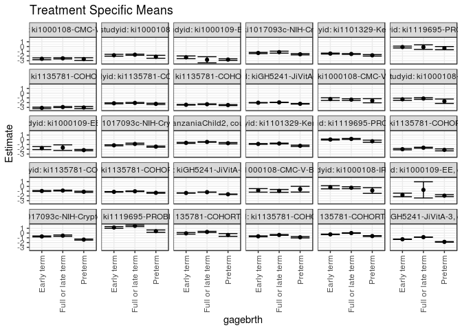

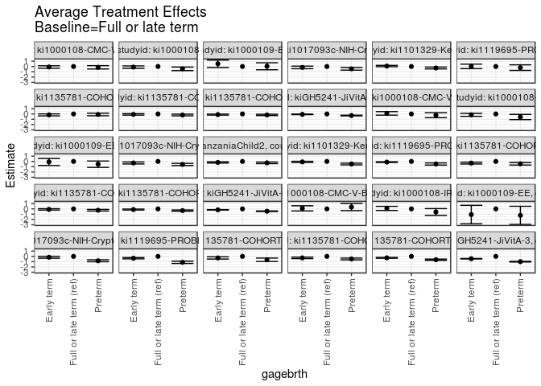

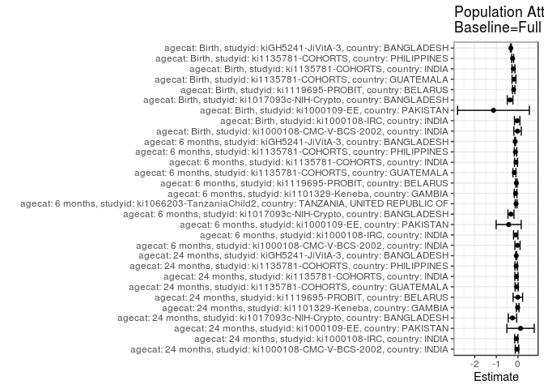

## Results Table

### Parameter: TSM

| agecat | studyid | country | intervention_level | baseline_level | estimate | ci_lower | ci_upper |
| --- | --- | --- | --- | --- | --- | --- | --- |
| Birth | ki1000108-CMC-V-BCS-2002 | INDIA | Full or late term | NA | -0.9406693 | -1.2377731 | -0.6435656 |
| Birth | ki1000108-CMC-V-BCS-2002 | INDIA | Preterm | NA | -0.5866602 | -1.1912418 | 0.0179213 |
| Birth | ki1000108-CMC-V-BCS-2002 | INDIA | Early term | NA | -0.8357998 | -1.2058861 | -0.4657135 |
| Birth | ki1000108-IRC | INDIA | Full or late term | NA | -0.2730507 | -0.4782784 | -0.0678229 |
| Birth | ki1000108-IRC | INDIA | Preterm | NA | -0.8542097 | -1.4584134 | -0.2500060 |
| Birth | ki1000108-IRC | INDIA | Early term | NA | -0.1776018 | -0.5076116 | 0.1524080 |
| Birth | ki1000109-EE | PAKISTAN | Full or late term | NA | -0.7272338 | -2.4339521 | 0.9794844 |
| Birth | ki1000109-EE | PAKISTAN | Preterm | NA | -1.9448555 | -2.1492075 | -1.7405034 |
| Birth | ki1000109-EE | PAKISTAN | Early term | NA | -1.8003098 | -2.1786789 | -1.4219407 |
| Birth | ki1017093c-NIH-Crypto | BANGLADESH | Full or late term | NA | -0.5450545 | -0.6911318 | -0.3989773 |
| Birth | ki1017093c-NIH-Crypto | BANGLADESH | Preterm | NA | -1.3787064 | -1.4914218 | -1.2659909 |
| Birth | ki1017093c-NIH-Crypto | BANGLADESH | Early term | NA | -0.7095619 | -0.8140077 | -0.6051160 |
| Birth | ki1119695-PROBIT | BELARUS | Full or late term | NA | 1.5251467 | 1.3690061 | 1.6812874 |
| Birth | ki1119695-PROBIT | BELARUS | Preterm | NA | 0.4045765 | 0.1539136 | 0.6552393 |
| Birth | ki1119695-PROBIT | BELARUS | Early term | NA | 1.1715628 | 0.9899067 | 1.3532190 |
| Birth | ki1135781-COHORTS | GUATEMALA | Full or late term | NA | 0.2385038 | 0.1140095 | 0.3629981 |
| Birth | ki1135781-COHORTS | GUATEMALA | Preterm | NA | -0.4026891 | -0.6958379 | -0.1095404 |
| Birth | ki1135781-COHORTS | GUATEMALA | Early term | NA | -0.0582737 | -0.2266376 | 0.1100902 |
| Birth | ki1135781-COHORTS | INDIA | Full or late term | NA | -0.3978507 | -0.4868830 | -0.3088183 |
| Birth | ki1135781-COHORTS | INDIA | Preterm | NA | -0.8885085 | -1.0308536 | -0.7461635 |
| Birth | ki1135781-COHORTS | INDIA | Early term | NA | -0.6829570 | -0.7810536 | -0.5848604 |
| Birth | ki1135781-COHORTS | PHILIPPINES | Full or late term | NA | -0.0014878 | -0.0596894 | 0.0567138 |
| Birth | ki1135781-COHORTS | PHILIPPINES | Preterm | NA | -0.6320024 | -0.7300858 | -0.5339190 |
| Birth | ki1135781-COHORTS | PHILIPPINES | Early term | NA | -0.2789011 | -0.3360290 | -0.2217732 |
| Birth | kiGH5241-JiVitA-3 | BANGLADESH | Full or late term | NA | -0.8586971 | -0.8914932 | -0.8259011 |
| Birth | kiGH5241-JiVitA-3 | BANGLADESH | Preterm | NA | -1.8595272 | -1.9180158 | -1.8010385 |
| Birth | kiGH5241-JiVitA-3 | BANGLADESH | Early term | NA | -1.3047708 | -1.3493132 | -1.2602284 |
| 6 months | ki1000108-CMC-V-BCS-2002 | INDIA | Full or late term | NA | -1.3626088 | -1.5448108 | -1.1804068 |
| 6 months | ki1000108-CMC-V-BCS-2002 | INDIA | Preterm | NA | -1.5954910 | -2.0352088 | -1.1557732 |
| 6 months | ki1000108-CMC-V-BCS-2002 | INDIA | Early term | NA | -1.2530630 | -1.5333012 | -0.9728247 |

[output cut: 60 more lines]

### Parameter: E(Y)

| agecat | studyid | country | intervention_level | baseline_level | estimate | ci_lower | ci_upper |
| --- | --- | --- | --- | --- | --- | --- | --- |
| Birth | ki1000108-CMC-V-BCS-2002 | INDIA | NA | NA | -0.9611957 | -1.1776967 | -0.7446946 |
| Birth | ki1000108-IRC | INDIA | NA | NA | -0.3102981 | -0.4751168 | -0.1454794 |
| Birth | ki1000109-EE | PAKISTAN | NA | NA | -1.8608750 | -2.0482045 | -1.6735455 |
| Birth | ki1017093c-NIH-Crypto | BANGLADESH | NA | NA | -0.9094945 | -0.9809370 | -0.8380521 |
| Birth | ki1119695-PROBIT | BELARUS | NA | NA | 1.3269446 | 1.1683850 | 1.4855041 |
| Birth | ki1135781-COHORTS | GUATEMALA | NA | NA | 0.0530794 | -0.0441925 | 0.1503513 |
| Birth | ki1135781-COHORTS | INDIA | NA | NA | -0.6072158 | -0.6675691 | -0.5468624 |
| Birth | ki1135781-COHORTS | PHILIPPINES | NA | NA | -0.2492460 | -0.2884729 | -0.2100192 |
| Birth | kiGH5241-JiVitA-3 | BANGLADESH | NA | NA | -1.1878459 | -1.2167939 | -1.1588980 |
| 6 months | ki1000108-CMC-V-BCS-2002 | INDIA | NA | NA | -1.3856004 | -1.5319935 | -1.2392073 |
| 6 months | ki1000108-IRC | INDIA | NA | NA | -1.2321263 | -1.3660720 | -1.0981806 |
| 6 months | ki1000109-EE | PAKISTAN | NA | NA | -2.0835567 | -2.2027557 | -1.9643578 |
| 6 months | ki1017093c-NIH-Crypto | BANGLADESH | NA | NA | -1.1986783 | -1.2700937 | -1.1272630 |
| 6 months | ki1066203-TanzaniaChild2 | TANZANIA, UNITED REPUBLIC OF | NA | NA | -0.5419570 | -0.5926042 | -0.4913098 |
| 6 months | ki1101329-Keneba | GAMBIA | NA | NA | -0.8948084 | -0.9510697 | -0.8385471 |
| 6 months | ki1119695-PROBIT | BELARUS | NA | NA | 0.1069986 | 0.0122286 | 0.2017686 |
| 6 months | ki1135781-COHORTS | GUATEMALA | NA | NA | -1.8315428 | -1.9081267 | -1.7549589 |
| 6 months | ki1135781-COHORTS | INDIA | NA | NA | -0.9630335 | -1.0220763 | -0.9039908 |
| 6 months | ki1135781-COHORTS | PHILIPPINES | NA | NA | -1.1409862 | -1.1830414 | -1.0989310 |
| 6 months | kiGH5241-JiVitA-3 | BANGLADESH | NA | NA | -1.3392722 | -1.3625791 | -1.3159653 |
| 24 months | ki1000108-CMC-V-BCS-2002 | INDIA | NA | NA | -2.5319389 | -2.6335015 | -2.4303762 |
| 24 months | ki1000108-IRC | INDIA | NA | NA | -1.7964915 | -1.8912047 | -1.7017782 |
| 24 months | ki1000109-EE | PAKISTAN | NA | NA | -2.6699900 | -2.8138051 | -2.5261749 |
| 24 months | ki1017093c-NIH-Crypto | BANGLADESH | NA | NA | -1.4412646 | -1.5249156 | -1.3576135 |
| 24 months | ki1101329-Keneba | GAMBIA | NA | NA | -1.5800865 | -1.6398819 | -1.5202911 |
| 24 months | ki1119695-PROBIT | BELARUS | NA | NA | -0.1314048 | -0.4282725 | 0.1654630 |
| 24 months | ki1135781-COHORTS | GUATEMALA | NA | NA | -2.9911195 | -3.0733804 | -2.9088586 |
| 24 months | ki1135781-COHORTS | INDIA | NA | NA | -2.1289450 | -2.1901830 | -2.0677069 |
| 24 months | ki1135781-COHORTS | PHILIPPINES | NA | NA | -2.4144884 | -2.4596605 | -2.3693164 |
| 24 months | kiGH5241-JiVitA-3 | BANGLADESH | NA | NA | -2.0218641 | -2.0501149 | -1.9936133 |

### Parameter: ATE

| agecat | studyid | country | intervention_level | baseline_level | estimate | ci_lower | ci_upper |
| --- | --- | --- | --- | --- | --- | --- | --- |
| Birth | ki1000108-CMC-V-BCS-2002 | INDIA | Full or late term | Full or late term | 0.0000000 | 0.0000000 | 0.0000000 |
| Birth | ki1000108-CMC-V-BCS-2002 | INDIA | Preterm | Full or late term | 0.3540091 | -0.3235414 | 1.0315596 |
| Birth | ki1000108-CMC-V-BCS-2002 | INDIA | Early term | Full or late term | 0.1048695 | -0.3858072 | 0.5955462 |
| Birth | ki1000108-IRC | INDIA | Full or late term | Full or late term | 0.0000000 | 0.0000000 | 0.0000000 |
| Birth | ki1000108-IRC | INDIA | Preterm | Full or late term | -0.5811590 | -1.2201205 | 0.0578025 |
| Birth | ki1000108-IRC | INDIA | Early term | Full or late term | 0.0954489 | -0.2948772 | 0.4857750 |
| Birth | ki1000109-EE | PAKISTAN | Full or late term | Full or late term | 0.0000000 | 0.0000000 | 0.0000000 |
| Birth | ki1000109-EE | PAKISTAN | Preterm | Full or late term | -1.2176216 | -2.9363181 | 0.5010748 |
| Birth | ki1000109-EE | PAKISTAN | Early term | Full or late term | -1.0730760 | -2.8198579 | 0.6737060 |
| Birth | ki1017093c-NIH-Crypto | BANGLADESH | Full or late term | Full or late term | 0.0000000 | 0.0000000 | 0.0000000 |
| Birth | ki1017093c-NIH-Crypto | BANGLADESH | Preterm | Full or late term | -0.8336518 | -1.0181633 | -0.6491404 |
| Birth | ki1017093c-NIH-Crypto | BANGLADESH | Early term | Full or late term | -0.1645073 | -0.3439988 | 0.0149841 |
| Birth | ki1119695-PROBIT | BELARUS | Full or late term | Full or late term | 0.0000000 | 0.0000000 | 0.0000000 |
| Birth | ki1119695-PROBIT | BELARUS | Preterm | Full or late term | -1.1205703 | -1.3393415 | -0.9017991 |
| Birth | ki1119695-PROBIT | BELARUS | Early term | Full or late term | -0.3535839 | -0.4736826 | -0.2334852 |
| Birth | ki1135781-COHORTS | GUATEMALA | Full or late term | Full or late term | 0.0000000 | 0.0000000 | 0.0000000 |
| Birth | ki1135781-COHORTS | GUATEMALA | Preterm | Full or late term | -0.6411929 | -0.9597977 | -0.3225881 |
| Birth | ki1135781-COHORTS | GUATEMALA | Early term | Full or late term | -0.2967775 | -0.5063160 | -0.0872391 |
| Birth | ki1135781-COHORTS | INDIA | Full or late term | Full or late term | 0.0000000 | 0.0000000 | 0.0000000 |
| Birth | ki1135781-COHORTS | INDIA | Preterm | Full or late term | -0.4906579 | -0.6587930 | -0.3225227 |
| Birth | ki1135781-COHORTS | INDIA | Early term | Full or late term | -0.2851064 | -0.4173704 | -0.1528423 |
| Birth | ki1135781-COHORTS | PHILIPPINES | Full or late term | Full or late term | 0.0000000 | 0.0000000 | 0.0000000 |
| Birth | ki1135781-COHORTS | PHILIPPINES | Preterm | Full or late term | -0.6305146 | -0.7444989 | -0.5165303 |
| Birth | ki1135781-COHORTS | PHILIPPINES | Early term | Full or late term | -0.2774133 | -0.3589017 | -0.1959250 |
| Birth | kiGH5241-JiVitA-3 | BANGLADESH | Full or late term | Full or late term | 0.0000000 | 0.0000000 | 0.0000000 |
| Birth | kiGH5241-JiVitA-3 | BANGLADESH | Preterm | Full or late term | -1.0008300 | -1.0639278 | -0.9377322 |
| Birth | kiGH5241-JiVitA-3 | BANGLADESH | Early term | Full or late term | -0.4460737 | -0.4950823 | -0.3970651 |
| 6 months | ki1000108-CMC-V-BCS-2002 | INDIA | Full or late term | Full or late term | 0.0000000 | 0.0000000 | 0.0000000 |
| 6 months | ki1000108-CMC-V-BCS-2002 | INDIA | Preterm | Full or late term | -0.2328822 | -0.7092663 | 0.2435019 |
| 6 months | ki1000108-CMC-V-BCS-2002 | INDIA | Early term | Full or late term | 0.1095458 | -0.2241572 | 0.4432489 |

[output cut: 60 more lines]

### Parameter: PAR

| agecat | studyid | country | intervention_level | baseline_level | estimate | ci_lower | ci_upper |
| --- | --- | --- | --- | --- | --- | --- | --- |
| Birth | ki1000108-CMC-V-BCS-2002 | INDIA | Full or late term | NA | -0.0205263 | -0.1928557 | 0.1518030 |
| Birth | ki1000108-IRC | INDIA | Full or late term | NA | -0.0372474 | -0.1623531 | 0.0878582 |
| Birth | ki1000109-EE | PAKISTAN | Full or late term | NA | -1.1336412 | -2.7915792 | 0.5242969 |
| Birth | ki1017093c-NIH-Crypto | BANGLADESH | Full or late term | NA | -0.3644400 | -0.4951660 | -0.2337140 |
| Birth | ki1119695-PROBIT | BELARUS | Full or late term | NA | -0.1982022 | -0.2528525 | -0.1435519 |
| Birth | ki1135781-COHORTS | GUATEMALA | Full or late term | NA | -0.1854244 | -0.2746232 | -0.0962255 |
| Birth | ki1135781-COHORTS | INDIA | Full or late term | NA | -0.2093651 | -0.2780459 | -0.1406843 |
| Birth | ki1135781-COHORTS | PHILIPPINES | Full or late term | NA | -0.2477582 | -0.2958505 | -0.1996659 |
| Birth | kiGH5241-JiVitA-3 | BANGLADESH | Full or late term | NA | -0.3291488 | -0.3511518 | -0.3071458 |
| 6 months | ki1000108-CMC-V-BCS-2002 | INDIA | Full or late term | NA | -0.0229916 | -0.1426135 | 0.0966303 |
| 6 months | ki1000108-IRC | INDIA | Full or late term | NA | -0.1039088 | -0.2039437 | -0.0038740 |
| 6 months | ki1000109-EE | PAKISTAN | Full or late term | NA | -0.4301362 | -1.0092987 | 0.1490264 |
| 6 months | ki1017093c-NIH-Crypto | BANGLADESH | Full or late term | NA | -0.3251616 | -0.4639861 | -0.1863372 |
| 6 months | ki1066203-TanzaniaChild2 | TANZANIA, UNITED REPUBLIC OF | Full or late term | NA | -0.0867375 | -0.1272917 | -0.0461833 |
| 6 months | ki1101329-Keneba | GAMBIA | Full or late term | NA | -0.1116345 | -0.1701032 | -0.0531658 |
| 6 months | ki1119695-PROBIT | BELARUS | Full or late term | NA | -0.0741761 | -0.1082750 | -0.0400773 |
| 6 months | ki1135781-COHORTS | GUATEMALA | Full or late term | NA | -0.1646400 | -0.2352422 | -0.0940378 |
| 6 months | ki1135781-COHORTS | INDIA | Full or late term | NA | -0.0916889 | -0.1594048 | -0.0239730 |
| 6 months | ki1135781-COHORTS | PHILIPPINES | Full or late term | NA | -0.1157561 | -0.1680614 | -0.0634508 |
| 6 months | kiGH5241-JiVitA-3 | BANGLADESH | Full or late term | NA | -0.1319545 | -0.1488556 | -0.1150534 |
| 24 months | ki1000108-CMC-V-BCS-2002 | INDIA | Full or late term | NA | -0.0454825 | -0.1260873 | 0.0351222 |
| 24 months | ki1000108-IRC | INDIA | Full or late term | NA | -0.0763480 | -0.1488963 | -0.0037997 |
| 24 months | ki1000109-EE | PAKISTAN | Full or late term | NA | 0.1207243 | -0.5112745 | 0.7527231 |
| 24 months | ki1017093c-NIH-Crypto | BANGLADESH | Full or late term | NA | -0.2557129 | -0.4477795 | -0.0636463 |
| 24 months | ki1101329-Keneba | GAMBIA | Full or late term | NA | -0.0129988 | -0.0744343 | 0.0484367 |
| 24 months | ki1119695-PROBIT | BELARUS | Full or late term | NA | -0.0057759 | -0.2257182 | 0.2141665 |
| 24 months | ki1135781-COHORTS | GUATEMALA | Full or late term | NA | -0.0618155 | -0.1339062 | 0.0102752 |
| 24 months | ki1135781-COHORTS | INDIA | Full or late term | NA | -0.0715315 | -0.1423321 | -0.0007309 |
| 24 months | ki1135781-COHORTS | PHILIPPINES | Full or late term | NA | -0.0843348 | -0.1402803 | -0.0283893 |
| 24 months | kiGH5241-JiVitA-3 | BANGLADESH | Full or late term | NA | -0.0779051 | -0.1002326 | -0.0555777 |